# NOAA Storm Data Analysis

Philong Ho

2/4/2020

# NOAA Storm Data Analysis: Exploring the Impact of Weather Events

## Synopsis

Storms and other severe weather events can cause both public health and economic problems for communities and municipalities. Many severe events can result in fatalities, injuries, and property damage, and preventing such outcomes to the extent possible is a key concern.

This project involves exploring the U.S. National Oceanic and Atmospheric Administration’s (NOAA) storm database. This database tracks characteristics of major storms and weather events in the United States, including when and where they occur, as well as estimates of any fatalities, injuries, and property damage.

## Data Processing

The data for this assignment come in the form of a comma-separated-value file compressed via the bzip2 algorithm to reduce its size. You can download the file from the course web site:

- [Storm Data [47mb]](https://d396qusza40orc.cloudfront.net/repdata%2Fdata%2FStormData.csv.bz2)

There is also some documentation of the database available. Here you will find how some of the variables are constructed/defined.

- National Weather Service [Storm Data Documentation](https://d396qusza40orc.cloudfront.net/repdata%2Fpeer2_doc%2Fpd01016005curr.pdf)
- National Climatic Data Center Storm Events [FAQ](https://d396qusza40orc.cloudfront.net/repdata%2Fpeer2_doc%2FNCDC%20Storm%20Events-FAQ%20Page.pdf)

The events in the database start in the year 1950 and end in November 2011. In the earlier years of the database there are generally fewer events recorded, most likely due to a lack of good records. More recent years should be considered more complete.

Since the data is in the form of a comma-separated-value (csv) file, we can use the read.csv() function to read it.

```r
storm_data <- read.csv("repdata_data_Stormdata.csv", sep = ",", header = TRUE)
str(storm_data)
```

```
## 'data.frame':    902297 obs. of  37 variables:
##  $ STATE__   : num  1 1 1 1 1 1 1 1 1 1 ...
##  $ BGN_DATE  : Factor w/ 16335 levels "1/1/1966 0:00:00",..: 6523 6523 4242 11116 2224 2224 2260 383 3980 3980 ...
##  $ BGN_TIME  : Factor w/ 3608 levels "00:00:00 AM",..: 272 287 2705 1683 2584 3186 242 1683 3186 3186 ...
##  $ TIME_ZONE : Factor w/ 22 levels "ADT","AKS","AST",..: 7 7 7 7 7 7 7 7 7 7 ...
##  $ COUNTY    : num  97 3 57 89 43 77 9 123 125 57 ...
##  $ COUNTYNAME: Factor w/ 29601 levels "","5NM E OF MACKINAC BRIDGE TO PRESQUE ISLE LT MI",..: 13513 1873 4598 10592 4372 10094 1973 23873 24418 4598 ...
##  $ STATE     : Factor w/ 72 levels "AK","AL","AM",..: 2 2 2 2 2 2 2 2 2 2 ...
##  $ EVTYPE    : Factor w/ 985 levels "   HIGH SURF ADVISORY",..: 834 834 834 834 834 834 834 834 834 834 ...
##  $ BGN_RANGE : num  0 0 0 0 0 0 0 0 0 0 ...
##  $ BGN_AZI   : Factor w/ 35 levels "","  N"," NW",..: 1 1 1 1 1 1 1 1 1 1 ...
##  $ BGN_LOCATI: Factor w/ 54429 levels "","- 1 N Albion",..: 1 1 1 1 1 1 1 1 1 1 ...
##  $ END_DATE  : Factor w/ 6663 levels "","1/1/1993 0:00:00",..: 1 1 1 1 1 1 1 1 1 1 ...
##  $ END_TIME  : Factor w/ 3647 levels ""," 0900CST",..: 1 1 1 1 1 1 1 1 1 1 ...
##  $ COUNTY_END: num  0 0 0 0 0 0 0 0 0 0 ...
```

[output cut: 23 more lines]

The data has 902297 observations and 37 variables, but we only need data relevant to the weather events and its impact. We can create a new dataset with these characteristics.

```r
storm_data1 <- storm_data[, c("EVTYPE", "FATALITIES", "INJURIES", "PROPDMG", "PROPDMGEXP", "CROPDMG", "CROPDMGEXP")]
str(storm_data1)
```

```
## 'data.frame':    902297 obs. of  7 variables:
##  $ EVTYPE    : Factor w/ 985 levels "   HIGH SURF ADVISORY",..: 834 834 834 834 834 834 834 834 834 834 ...
##  $ FATALITIES: num  0 0 0 0 0 0 0 0 1 0 ...
##  $ INJURIES  : num  15 0 2 2 2 6 1 0 14 0 ...
##  $ PROPDMG   : num  25 2.5 25 2.5 2.5 2.5 2.5 2.5 25 25 ...
##  $ PROPDMGEXP: Factor w/ 19 levels "","-","?","+",..: 17 17 17 17 17 17 17 17 17 17 ...
##  $ CROPDMG   : num  0 0 0 0 0 0 0 0 0 0 ...
##  $ CROPDMGEXP: Factor w/ 9 levels "","?","0","2",..: 1 1 1 1 1 1 1 1 1 1 ...
```

Looking at the str of storm_data1, we can see that there are variables named “PROPDMGEXP” and “CROPDMGEXP”. These are the exponent values of “PROPDMG” and “CROPDMG” respectively and they are characterized by “H,h,K,k,M,m,B,b,+,-,?,0,1,2,3,4,5,6,7,8, and blank-character”. We need only concern ourselves with the values “H, K, M, B” which are 100, 1000, 10^6, and 10^9 respectively. We can create new columns in storm_data1 to properly reflect the values of the property and crop damage.

```r
storm_data1$REALPROP = 0
storm_data1[storm_data1$PROPDMGEXP == "H", ]$REALPROP = storm_data1[storm_data1$PROPDMGEXP == "H", ]$PROPDMG * 100
storm_data1[storm_data1$PROPDMGEXP == "K", ]$REALPROP = storm_data1[storm_data1$PROPDMGEXP == "K", ]$PROPDMG * 1000
storm_data1[storm_data1$PROPDMGEXP == "M", ]$REALPROP = storm_data1[storm_data1$PROPDMGEXP == "M", ]$PROPDMG * 10^6
storm_data1[storm_data1$PROPDMGEXP == "B", ]$REALPROP = storm_data1[storm_data1$PROPDMGEXP == "B", ]$PROPDMG * 10^9

storm_data1$REALCROP = 0
storm_data1[storm_data1$CROPDMGEXP == "H", ]$REALCROP = storm_data1[storm_data1$CROPDMGEXP == "H", ]$CROPDMG * 100
storm_data1[storm_data1$CROPDMGEXP == "K", ]$REALCROP = storm_data1[storm_data1$CROPDMGEXP == "K", ]$CROPDMG * 1000
storm_data1[storm_data1$CROPDMGEXP == "M", ]$REALCROP = storm_data1[storm_data1$CROPDMGEXP == "M", ]$CROPDMG * 10^6
storm_data1[storm_data1$CROPDMGEXP == "B", ]$REALCROP = storm_data1[storm_data1$CROPDMGEXP == "B", ]$CROPDMG * 10^9
```

## Results

First, we can look at the number of fatalities by weather event.

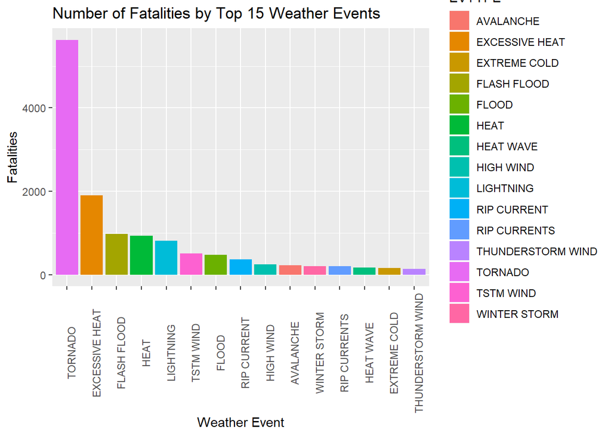

```r
library(ggplot2)
fatalities <- aggregate(FATALITIES ~ EVTYPE, data = storm_data1, sum)
fatalities <- fatalities[order(fatalities$FATALITIES, decreasing = TRUE), ][1:15, ] ## In decreasing order by top 15 events
g <- ggplot(fatalities, aes(x = reorder(EVTYPE, -FATALITIES), y = FATALITIES, fill = EVTYPE))
g + geom_bar(stat = "identity") + theme(axis.text.x = element_text(angle = 90)) + xlab("Weather Event") + ylab("Fatalities") + ggtitle("Number of Fatalities by Top 15 Weather Events")
```

We can see that Tornadoes cause the most fatalities in comparison to the other events.

Second, we can look at the number of injuries by weather event.

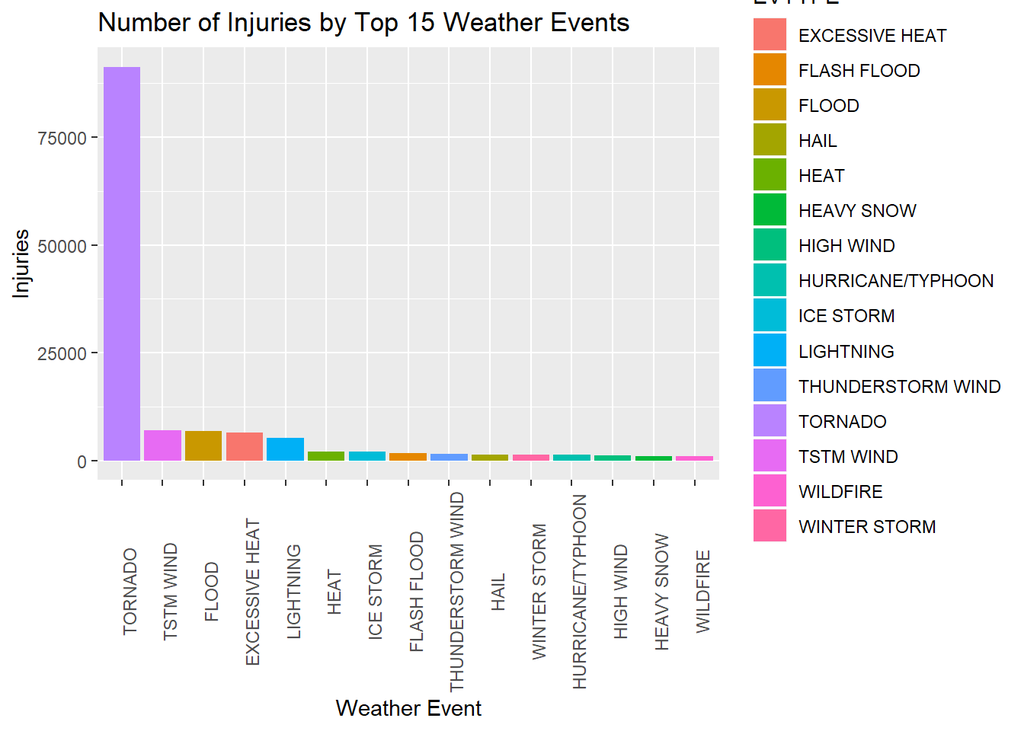

```r
injuries <- aggregate(INJURIES ~ EVTYPE, data = storm_data1, sum)
injuries <- injuries[order(injuries$INJURIES, decreasing = TRUE), ][1:15, ]
g1 <- ggplot(injuries, aes(x = reorder(EVTYPE, -INJURIES), y = INJURIES, fill = EVTYPE))
g1 + geom_bar(stat = "identity") + theme(axis.text.x = element_text(angle = 90)) + xlab("Weather Event") + ylab("Injuries") + ggtitle("Number of Injuries by Top 15 Weather Events")
```

Here, we can see that Tornadoes are once again leading over the other events.

Lastly, we can look at the total property and crop damage by weather event.

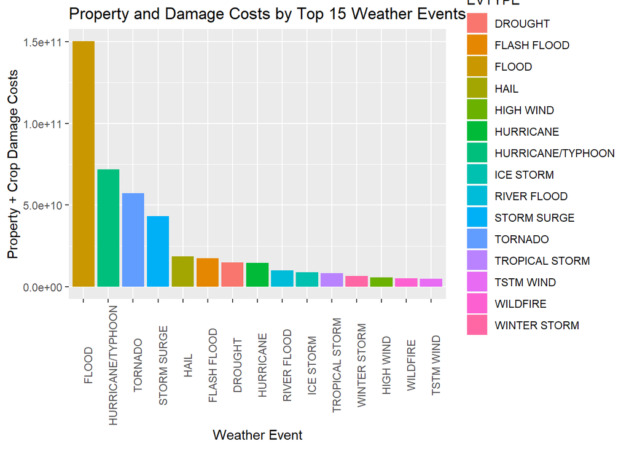

```r
propcrop <- aggregate(REALPROP+REALCROP ~ EVTYPE, data = storm_data1, sum)
names(propcrop) <- c("EVTYPE", "TOTALDMG")
propcrop <- propcrop[order(propcrop$TOTALDMG, decreasing = TRUE), ][1:15, ]
g2 <- ggplot(propcrop, aes(x = reorder(EVTYPE, -TOTALDMG), y = TOTALDMG, fill = EVTYPE))
g2 + geom_bar(stat = "identity") + theme(axis.text.x = element_text(angle = 90)) + xlab("Weather Event") + ylab("Property + Crop Damage Costs") + ggtitle("Property and Damage Costs by Top 15 Weather Events")
```

Here, we can actually see that Floods are the leading cause of property and crop damage while Tornadoes are actually ranked third.